# Metatranscriptome analysis of *Eulimnogammarus verrucosus* microbiome

## Workflow

### Data preprocessing

The data were prepared as follows: (1) raw data were cleared from adapters, (2) from rRNA before project start.

The number of reads for each samples is given below.

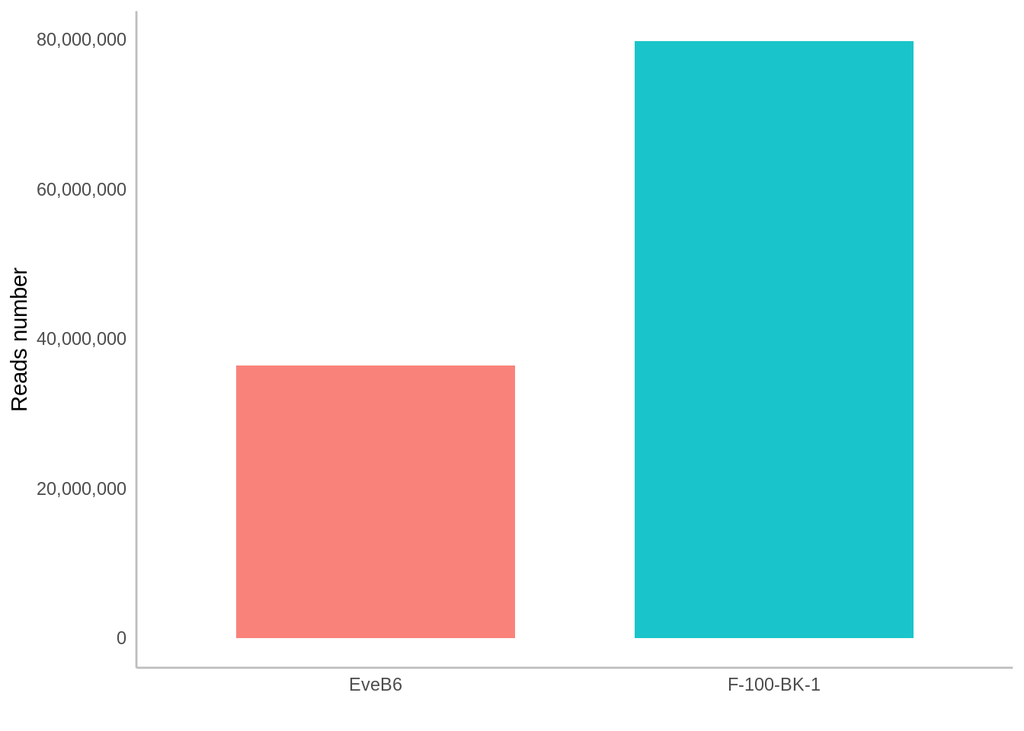

### BBDuk k-mers analysis

For analysis we used Silva DB (reference_SILVADB.fasta):

- Vortivella_SILVADB.fasta
- Peritrichia_SILVADB.fasta
- Ciliophora_SILVADB.fasta
- Eulimnogammarus_verrucosus_SILVADB.fasta

```bash
bbduk.sh -Xmx1g -in1=reads_R1.fastq.gz -in2=reads_R2.fastq.gz ref=reference_SILVADB.fasta k=50 hdist=0 outm=match_reads.fq out=no_match.fq stats=sample.stats.txt threads=2
```

We calculated the ratio **Сiliate reads / E. verrucosus reads**

| Сiliate | Eve_B6 | F-100-BK-1 |
| --- | --- | --- |
| Vorticella | 1.0106 | 1.0570 |
| Peritrichia | 1.0147 | 1.0690 |
| Ciliophora | 1.0202 | 1.0961 |

### BBDuk clear from muscle

Used an assembly of muscle of *Eulimnogammarus verrucosus* to clean microbiome.

```bash
bbduk.sh -Xmx2g -in1=reads_R1.fastq.gz -in2=reads_R2.fastq.gz ref=EveNEB_muscle.filtered.fasta -out1=reads_womuscleR1.fq -out2=reads_womuscleR2.fq k=50 hdist=0 stats=sample.stats.txt threads=2
```

Reads left after cleaning:

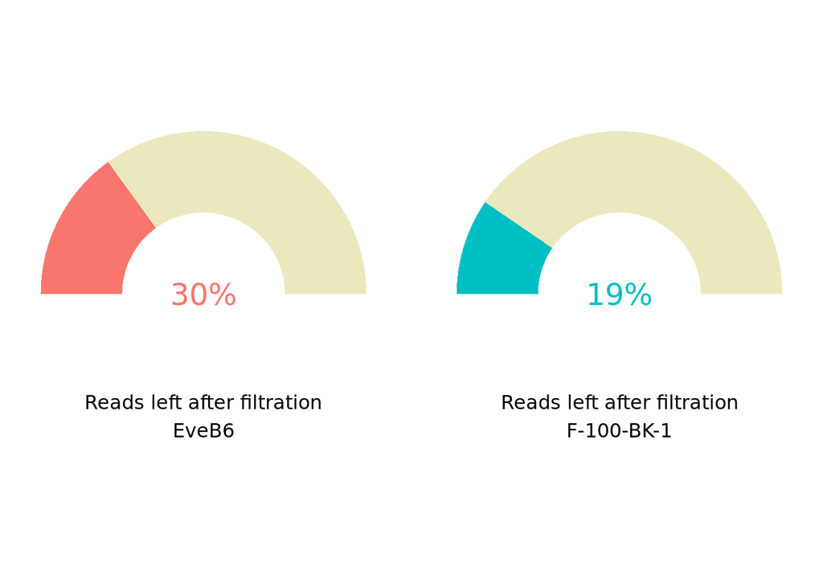

### Rcorrector correcting data

```bash
perl run_rcorrector.pl -1 /path/to/reads_womuscleR1.fq -2 /path/to/reads_womuscleR2.fq -t 2
```

Reads left after correction:

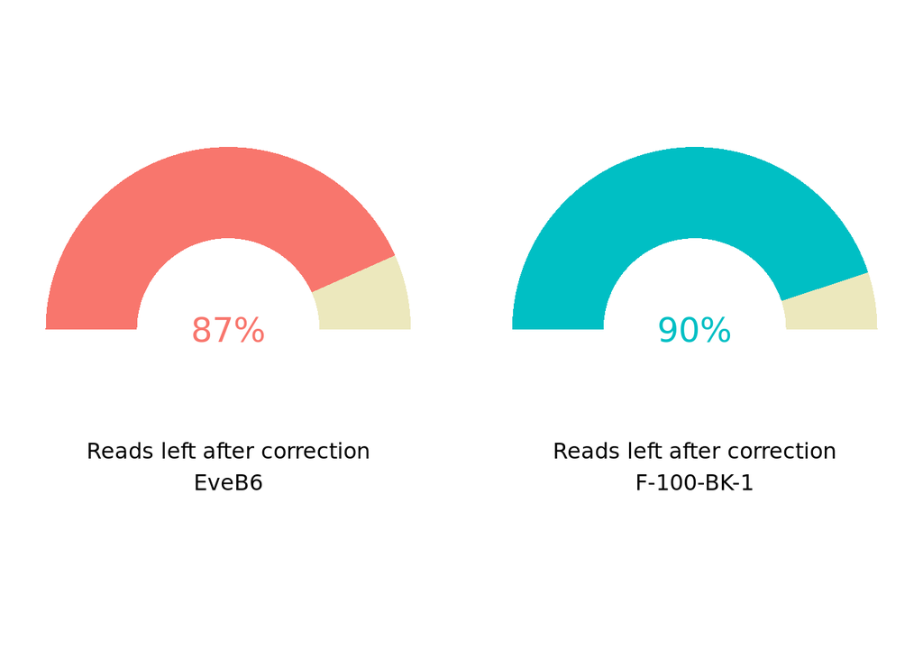

### Assembly

MEGAHIT

```bash
time megahit -1 reads_womuscleR1.cor.fq -2 reads_womuscleR2.cor.fq --memory 8e9 --num-cpu-threads 2 --out-prefix target --out-dir ./output_directory -f
```

rnaSPAdes

Samples differ in chain specificity:

```bash
./rnaspades.py -1 /path/to/EveB6_womuscleR1.cor.fq -2 /path/to/EveB6_womuscleR2.cor.fq -t 4 -m 50 -o /path/to/data_for_assembly/EveB6_rnasp --ss fr
```

```bash
./rnaspades.py -1 /path/to/F100-BK1_womuscleR1.cor.fq -2 /path/to/F100-BK1_womuscleR2.cor.fq -t 4 -m 50 -o /path/to/F100-BK1_rnasp --ss rf
```

Trinity

```bash
./Trinity --left /path/to/EveB6_womuscleR1.cor.fq --right /path/to/EveB6_womuscleR2.cor.fq --SS_lib_type FR --seqType fq --max_memory 50G --CPU 4 --output /path/to/EveB6_trinity
```

```bash
./Trinity --left /path/to/F100-BK1_womuscleR1.cor.fq --right /path/to/F100-BK1_womuscleR2.cor.fq --SS_lib_type RF --seqType fq --max_memory 50G --CPU 4 --output /path/to/F100_BK1_trinity
```

### Assembly results

Total contigs count:

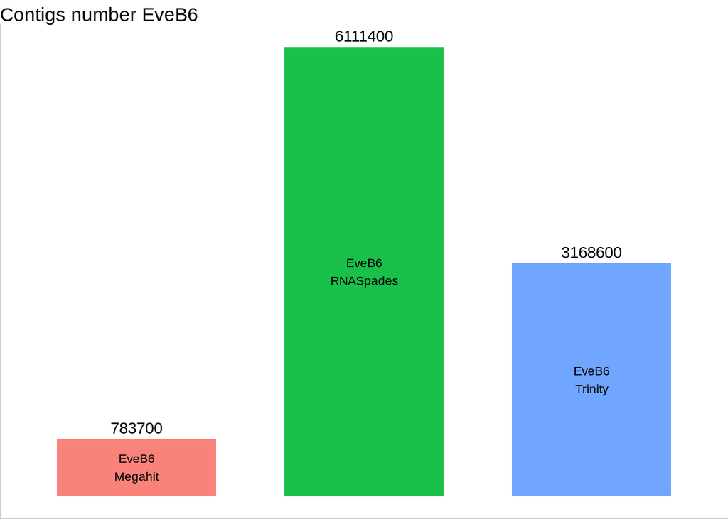

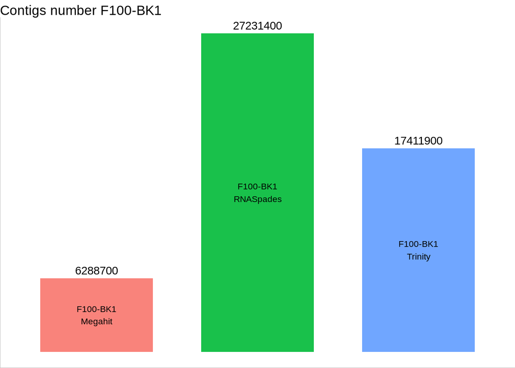

### QC assembly TransRate

```bash
transrate --assembly target_assembly.fa
```

Contig length distribution:

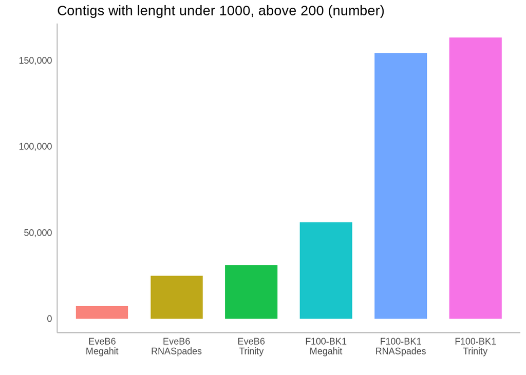

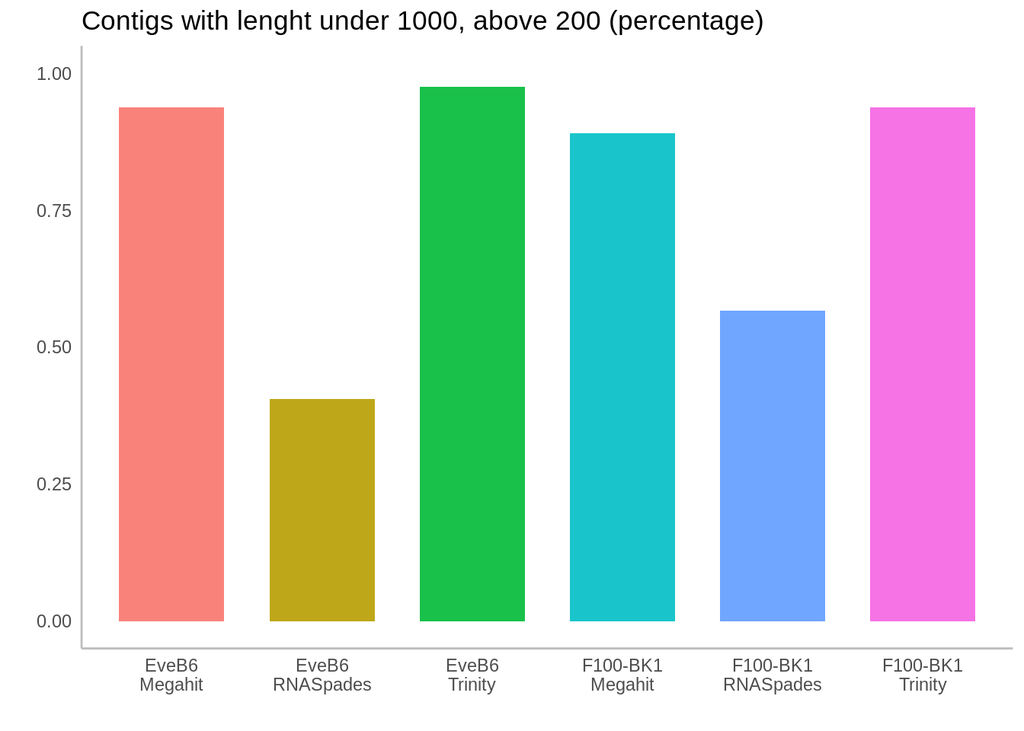

Less than 200 bp contigs are mostly found in the rnaSPAdes assembly.

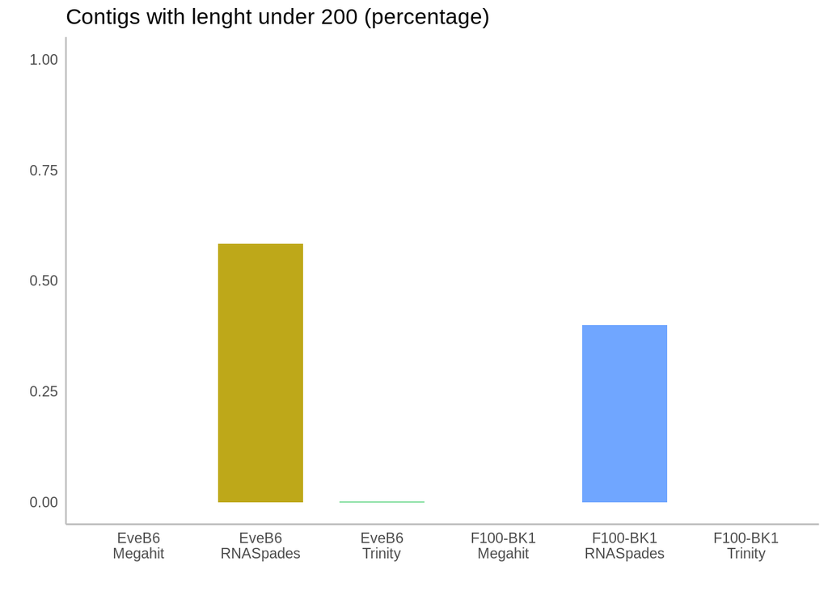

ORF contigs number:

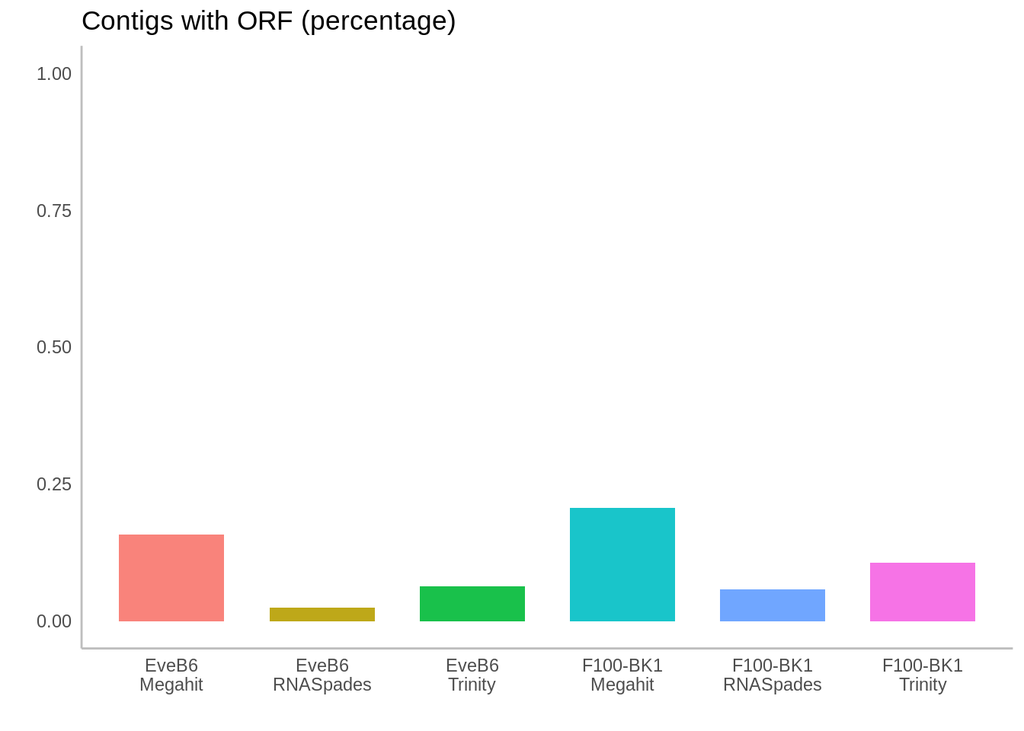

### QC assembly BUSCO

Databases were pre-downloaded. The launch was carried out using a script:

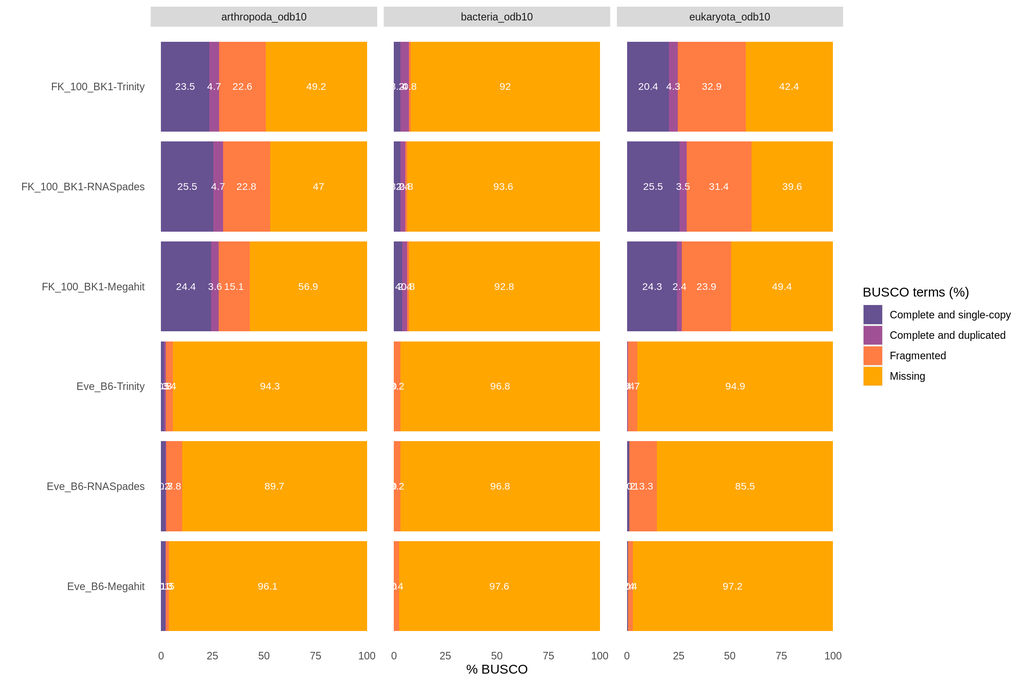

```bash
python3 busco_run.py
```

### Bowtie 2

A Bowtie 2 was used to estimate the amount of aligned reads.

```bash
bowtie2-build target_assembly
```

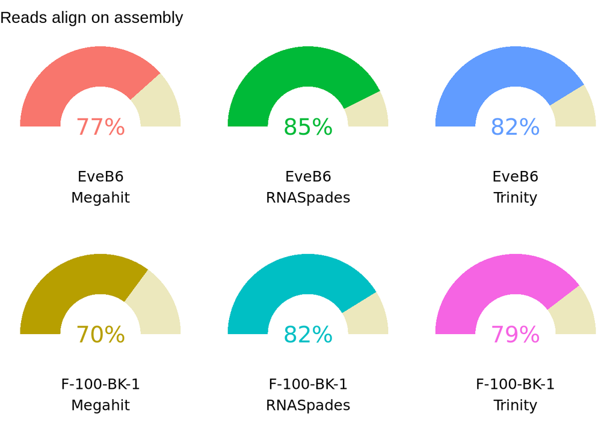

```bash
bowtie2 -p 10 -q --no-unal -k 20 -x target_assembly -1 reads_womuscleR1.cor.fq -2 reads_womuscleR2.cor.fq 2>align.stats.target.txt > logs.txt
```

### CD-HIT correction

```bash
./cd-hit-est -i target_assembly.fasta -o target_assembly_clear -c 0.95 -n 8
```

### QC after correction: TransRate

Total contigs count:

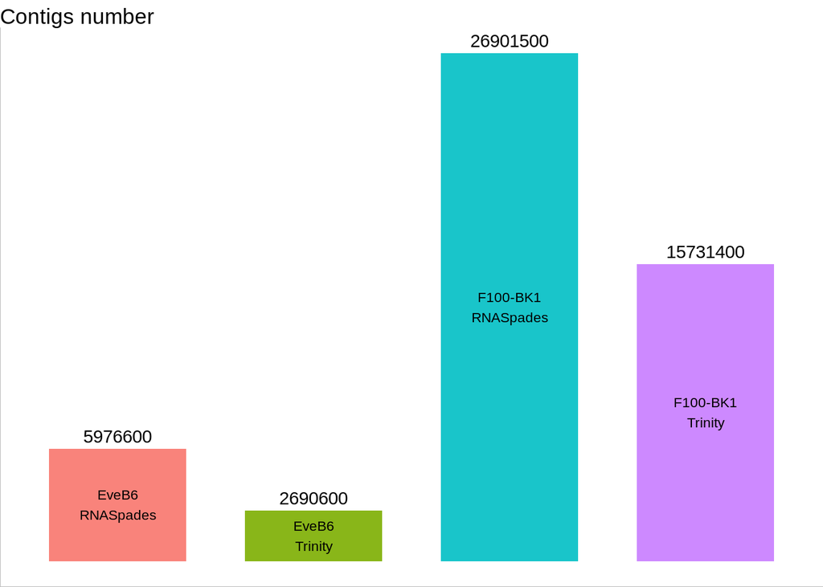

### QC after correction: BUSCO

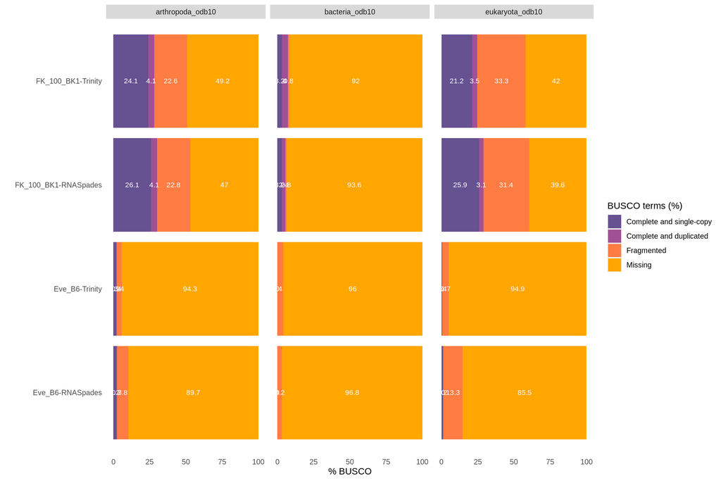

### Analysis of taxonomy

Used the base UniProtKB_Swiss-Prot:

```bash
mmseqs databases UniProtKB/Swiss-Prot UniProtKB_Swiss-ProtDB tmp
```

Prepare the bases:

```bash
mmseqs createdb target_assembly.fasta
mmseqs createdb UniProtKB_Swiss-Prot UniProtKB_Swiss-ProtDB
```

Prepare annotation base:

```bash
mmseqs createtaxdb UniProtKB_Swiss-ProtDB tmp
```

Building a taxonomy (-s - sensivity, use 2, 6, 7.5, final results on -s 7.5):

```bash
mmseqs taxonomy target_assembly UniProtKB_Swiss-ProtDB lca_result tmp -s X
```

Generate reports:

```bash
# Pavian
mmseqs taxonomyreport UniProtKB_Swiss-ProtDB lca_result taxonomyResult_report
# Krona
mmseqs taxonomyreport UniProtKB_Swiss-ProtDB lca_result report.html --report-mode 1
```

From the Pavian report take data on the distribution of taxa:

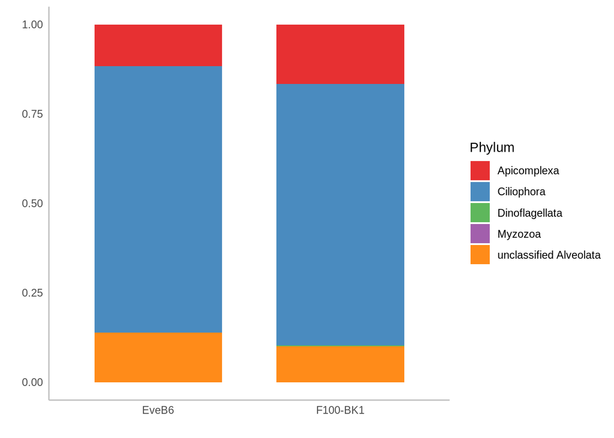

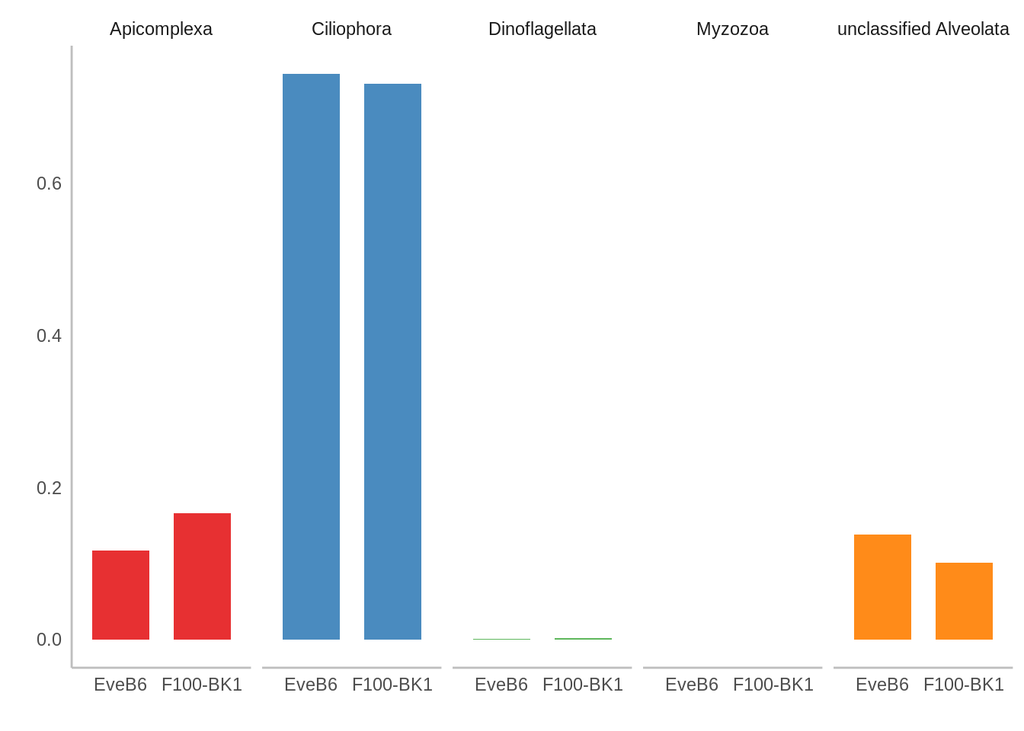

In details Ciliophora:

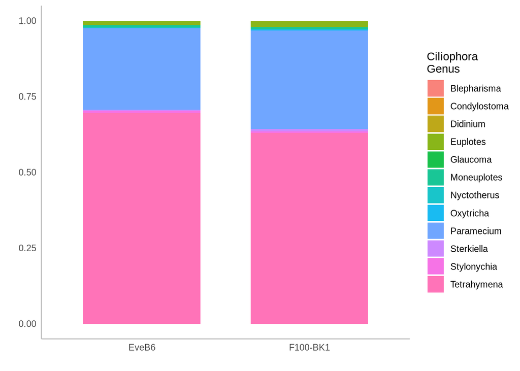

Unique genus for each sample:

[output not shown]